# R_phase2

Reza Pishkoo

#part A

```r
library(readxl)

input = read.csv("data/lyon_housing.csv")

input$date_transaction = as.Date(input$date_transaction)
input$type_purchase = as.factor(input$type_purchase)
input$type_property = as.factor(input$type_property)
input$date_construction = as.Date(input$date_construction)
input$district = as.factor(input$district)
input$latitude = as.double(input$latitude)
input$longitude = as.double(input$longitude)
```

در این cell ستون های با فرمت کاراکتر را فاکتور کردم و ستون های اعشاری را دابل کردم و ستون های به فرمت تاریخ هم Date کردم که در ادامه استفاده کنم.

```r
summary(input)
```

| date_transaction | type_purchase | type_property | rooms_count | surface_housing | surface_effective_usable | surface_terrain | parkings_count | price | address | district | latitude | longitude | date_construction |
| --- | --- | --- | --- | --- | --- | --- | --- | --- | --- | --- | --- | --- | --- |
| Min. :0016-07-01 | ancien:35562 | appartement:39832 | Min. :1.000 | Min. : 20.00 | Min. : 2.81 | Min. : 0.000 | Min. :0.0000 | Min. : 24000 | Length:40516 | Villeurbanne :10330 | Min. :45.72 | Min. :4.773 | Min. :0000-01-08 |
| 1st Qu.:0017-07-31 | VEFA : 4954 | maison : 684 | 1st Qu.:2.000 | 1st Qu.: 45.00 | 1st Qu.: 44.70 | 1st Qu.: 0.000 | 1st Qu.:0.0000 | 1st Qu.: 155273 | Class :character | Lyon 3e Arrondissement: 5974 | 1st Qu.:45.75 | 1st Qu.:4.831 | 1st Qu.:0006-03-30 |
| Median :0018-09-11 |  |  | Median :3.000 | Median : 63.00 | Median : 62.80 | Median : 0.000 | Median :1.0000 | Median : 220000 | Mode :character | Lyon 7e Arrondissement: 5289 | Median :45.76 | Median :4.854 | Median :0090-01-01 |
| Mean :0018-10-07 |  |  | Mean :2.792 | Mean : 65.24 | Mean : 63.53 | Mean : 3.765 | Mean :0.5993 | Mean : 255759 |  | Lyon 8e Arrondissement: 4626 | Mean :45.76 | Mean :4.852 | Mean :0058-12-03 |
| 3rd Qu.:0019-11-06 |  |  | 3rd Qu.:4.000 | 3rd Qu.: 80.00 | 3rd Qu.: 78.11 | 3rd Qu.: 0.000 | 3rd Qu.:1.0000 | 3rd Qu.: 309000 |  | Lyon 9e Arrondissement: 3342 | 3rd Qu.:45.77 | 3rd Qu.:4.876 | 3rd Qu.:0090-01-01 |
| Max. :0021-06-30 |  |  | Max. :6.000 | Max. :300.00 | Max. :270.67 | Max. :944.000 | Max. :3.0000 | Max. :2780000 |  | Lyon 5e Arrondissement: 2934 | Max. :45.81 | Max. :4.920 | Max. :0099-12-17 |
|  |  |  |  |  | `NA`s :14491 |  |  |  |  | (Other) : 8021 | `NA`s :143 | `NA`s :143 |  |

در این سامری تعداد NA های ستون های surface_effective_usable, latitude, longitude قابل مشاهده است و همچنین میانگین و ماکسیمم و مینیمم ستون های عددی بیان شده است. که در ادامه داده های معیوب ستون های latitudeو longitude را حذف میکنم.

```r
deleteNA <- function(nans){
  list_to_delete = vector()

  for (i in 1:length(nans)){
    if (nans[i]){
      list_to_delete = c(list_to_delete, i)
    }
  }
  return(list_to_delete)
}

l = deleteNA(is.na(input$latitude))

input = input[-c(l), ]
```

در این cell اندیس سطر های معیوب ستون های latitude و longitude را پیدا میکنم که تعداد آنها 143 تا است و آنها را حذف میکنم.

```r
summary(input)
```

| date_transaction | type_purchase | type_property | rooms_count | surface_housing | surface_effective_usable | surface_terrain | parkings_count | price | address | district | latitude | longitude | date_construction |
| --- | --- | --- | --- | --- | --- | --- | --- | --- | --- | --- | --- | --- | --- |
| Min. :0016-07-01 | ancien:35419 | appartement:39700 | Min. :1.000 | Min. : 20.00 | Min. : 2.81 | Min. : 0.000 | Min. :0.0000 | Min. : 24000 | Length:40373 | Villeurbanne :10300 | Min. :45.72 | Min. :4.773 | Min. :0000-01-08 |
| 1st Qu.:0017-08-01 | VEFA : 4954 | maison : 673 | 1st Qu.:2.000 | 1st Qu.: 45.00 | 1st Qu.: 44.69 | 1st Qu.: 0.000 | 1st Qu.:0.0000 | 1st Qu.: 155400 | Class :character | Lyon 3e Arrondissement: 5967 | 1st Qu.:45.75 | 1st Qu.:4.831 | 1st Qu.:0006-03-30 |
| Median :0018-09-12 |  |  | Median :3.000 | Median : 63.00 | Median : 62.80 | Median : 0.000 | Median :1.0000 | Median : 220000 | Mode :character | Lyon 7e Arrondissement: 5264 | Median :45.76 | Median :4.854 | Median :0090-01-01 |
| Mean :0018-10-08 |  |  | Mean :2.792 | Mean : 65.22 | Mean : 63.51 | Mean : 3.713 | Mean :0.5988 | Mean : 255835 |  | Lyon 8e Arrondissement: 4602 | Mean :45.76 | Mean :4.852 | Mean :0058-11-29 |
| 3rd Qu.:0019-11-07 |  |  | 3rd Qu.:4.000 | 3rd Qu.: 80.00 | 3rd Qu.: 78.09 | 3rd Qu.: 0.000 | 3rd Qu.:1.0000 | 3rd Qu.: 309000 |  | Lyon 9e Arrondissement: 3309 | 3rd Qu.:45.77 | 3rd Qu.:4.876 | 3rd Qu.:0090-01-01 |
| Max. :0021-06-30 |  |  | Max. :6.000 | Max. :300.00 | Max. :270.67 | Max. :944.000 | Max. :3.0000 | Max. :2780000 |  | Lyon 5e Arrondissement: 2933 | Max. :45.81 | Max. :4.920 | Max. :0099-12-17 |
|  |  |  |  |  | `NA`s :14435 |  |  |  |  | (Other) : 7998 |  |  |  |

در این سامری هم مشخص است که سطر های NA حذف شده اند.

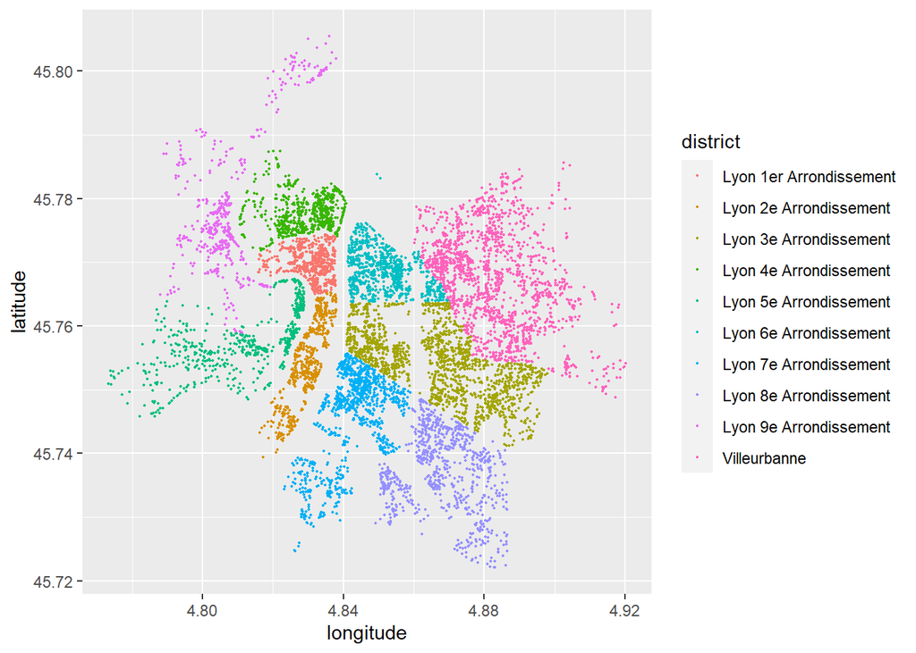

```r
library(ggplot2)
ggplot() +geom_point( data=input, aes(y=latitude, x=longitude, color = district), size = 0.4)
```

در این cell مختصات خانه ها را با توجه به اینکه در چه منطقه ای هستند دسته بندی کردم و نقشه آن را نمایش داده ام. که همانطور که قابل پیشبینی بود خانه های منطقه های یکسان در یک ناحیه متراکم نزیدک به هم قرار دارند.

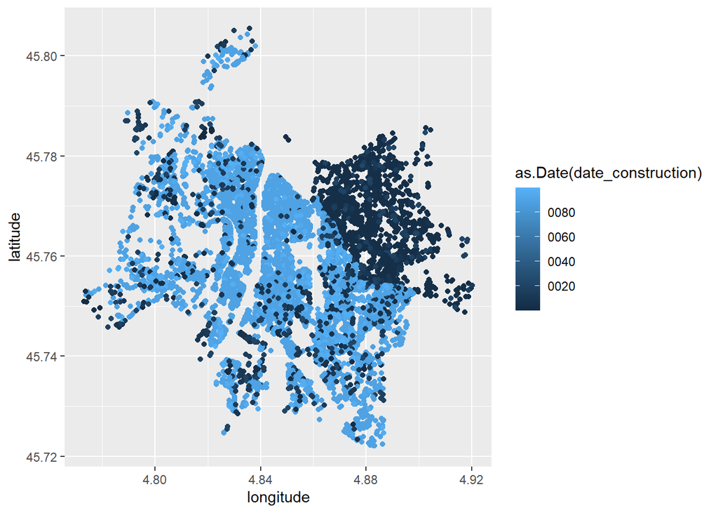

```r
library(ggplot2)

ggplot() +geom_point( data=input, aes(y=latitude, x=longitude, color = as.Date(date_construction)))
```

در این Cell خانه ها را بر حسب تاریخ ساخت دسته بندی کردم که همانطور که از نقشه میتوان فهمید خانه های قدیمی شهر در سمت بالا راست شهر تراکم زیادی دارند و میتوان گفت بافت قدیمی شهر آنجاست. و همچنین با مقایسه با نمودار بالا که منطقه ها را نشان میداد میتوان فهمید که منطقه Villeurbanne منطقه ای قدیمی است.

```r
library("rjson")
stations_json <- fromJSON(file = "data/station_coordinates.json")
```

```r
station_vec = vector()
latitudes_vec = vector()
longitudes_vec = vector()
for (part in stations_json){
  for (k in 1:length(part$stations)){
    station_vec = c(station_vec, part$stations[k])
    latitudes_vec = c(latitudes_vec, part$latitudes[k])
    longitudes_vec = c(longitudes_vec, part$longitudes[k])}}

station_frame = data.frame(station_vec, latitudes_vec, longitudes_vec)
```

فایل جیسون را میخوانم. و یک دیتافریم از روی آن میسازم که شامل سه ستون طول و عرض ایستگاه ها و نام آنها است.

```r
library(geosphere)
walkability = vector()
list_lat1 = input[, 12]
list_lon1 = input[, 13]
list_lat2 = station_frame[, 2]
list_lon2 = station_frame[, 3]
```

```r
for (house in 1:length(list_lat1)){
  lat1 = list_lat1[house]
  lon1 = list_lon1[house]
  distance = distm(c(lon1, lat1), cbind(list_lon2, list_lat2), fun = distHaversine)
  min_dist = min(distance)
  walkability = c(walkability, min_dist)
}
```

```r
input[, 15] = walkability
names(input)[15] = "walkability"
```

در سه cell بالا قصد دارم یک ستون به دیتافریم اضافه کنم که نشان دهنده فاصله تا نزدیک ترین ایستگاه مترو است.

```r
ppm = vector()
for(p in 1:length(input$price)){
  ppm = c(ppm, input[p, 9] / input[p, 5])
}
input[, 16] = ppm
names(input)[16] = "ppm"
```

در این cell هم یک ستون دیگر اضافه میکنم که نشان دهنده ی این است که هر خانه متری چند است. (price per meter)

```r
surface_room_reg = lm(input$rooms_count ~ input$surface_housing)
summary(surface_room_reg)
```

```
##
## Call:
## lm(formula = input$rooms_count ~ input$surface_housing)
##
## Residuals:
##     Min      1Q  Median      3Q     Max
## -8.0233 -0.3632  0.0224  0.3913  3.0407
##
## Coefficients:
##                        Estimate Std. Error t value Pr(>|t|)
## (Intercept)           0.5049851  0.0080618   62.64   <2e-16 ***
## input$surface_housing 0.0350612  0.0001134  309.07   <2e-16 ***
## ---
## Signif. codes:  0 '***' 0.001 '**' 0.01 '*' 0.05 '.' 0.1 ' ' 1
##
## Residual standard error: 0.6433 on 40371 degrees of freedom
## Multiple R-squared:  0.7029, Adjusted R-squared:  0.7029
## F-statistic: 9.553e+04 on 1 and 40371 DF,  p-value: < 2.2e-16
```

در این cell رابطه بین تعداد اتاق ها و مساحت خانه را بررسی میکنم که چون R squared به یک نزدیک هست میتوان فهمید که این دو ستون رابطه ی خطی دارند.

#part B

```r
maison_rooms = vector()
apartmant_rooms = vector()
for(c in 1:length(input$type_property)){
  if(input[c, 3] == "maison"){
    maison_rooms = c(maison_rooms, input[c, 4])
  }else{
    apartmant_rooms = c(apartmant_rooms, input[c, 4])
  }
}
t.test(maison_rooms, apartmant_rooms)
```

```
##
##  Welch Two Sample t-test
##
## data:  maison_rooms and apartmant_rooms
## t = 31.352, df = 695.15, p-value < 2.2e-16
## alternative hypothesis: true difference in means is not equal to 0
## 95 percent confidence interval:
##  1.327432 1.504795
## sample estimates:
## mean of x mean of y
##  4.184250  2.768136
```

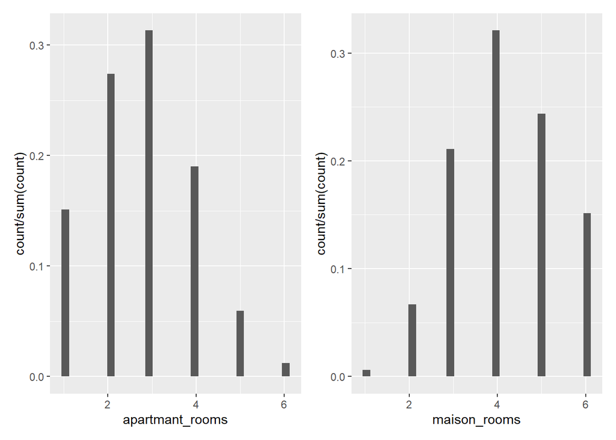

```r
library(patchwork)
(ggplot() + geom_histogram(aes(x=apartmant_rooms, y=..count../sum(..count..)))) +
(ggplot() + geom_histogram(aes(x=maison_rooms, y=..count../sum(..count..))))
```

در قسمت بالا تعداد اتاق های خانه و آپارتمان را مقایسه میکنم. فرض صفر را عدم تفاوت تعداد خانه ها گرفتم که از نتیجه t test و مقدار p value میتوان فهمید فرض عدم تفاوت را رد کرد و نتیجه گرفت که تعداد اتاق های خانه و اپارتمان متفاوت هست که از روی نمودار هم این نتیجه مشهود است که خانه ها به طور متوسط تعداد اتاق های بیشتری نسبت به آپارتمان ها دارند.

```r
library("gplots")
library("reshape2")
library("data.table")
h <- input[, c('rooms_count', 'type_property')]

frequency = dcast(as.data.table(h), rooms_count ~ type_property)
```

```
## Aggregate function missing, defaulting to 'length'
```

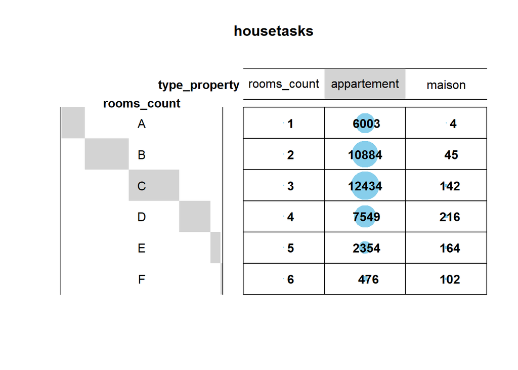

```r
dt = as.table(as.matrix(frequency))
balloonplot(t(dt), main = "housetasks", xlab = "type_property", ylab = "rooms_count", label = TRUE, show.margins = FALSE)
```

در ادامه توضیحات بالا مربوط به تعداد اتاق در این نمودار هم تعداد آپارتمان ها و خانه ها را بر اساس تعداد خواب میتوان مشاهده کرد.

```r
surface_room_reg = lm(data=input, surface_housing~rooms_count)
surface_room_yhat = predict(surface_room_reg, input)
summary(surface_room_reg)
```

```
##
## Call:
## lm(formula = surface_housing ~ rooms_count, data = input)
##
## Residuals:
##     Min      1Q  Median      3Q     Max
## -64.446  -8.397  -2.300   5.652 230.603
##
## Coefficients:
##             Estimate Std. Error t value Pr(>|t|)
## (Intercept)  9.25111    0.19661   47.05   <2e-16 ***
## rooms_count 20.04868    0.06487  309.07   <2e-16 ***
## ---
## Signif. codes:  0 '***' 0.001 '**' 0.01 '*' 0.05 '.' 0.1 ' ' 1
##
## Residual standard error: 15.38 on 40371 degrees of freedom
## Multiple R-squared:  0.7029, Adjusted R-squared:  0.7029
## F-statistic: 9.553e+04 on 1 and 40371 DF,  p-value: < 2.2e-16
```

در این قسمت رابطه تعداد اتاث با مساحت را بررسی میکنم. با توجه به مقادیر کم p value اگر فرض صفر را مستقل بودن در نظر بگیریم این فرض رد می شود و در نتیجه وابسته هستند. و همچنین R squared نزدیک به 1 است که باز هم مرتبط بودن را نشان میدهد. پس رابطه ای خطی بین تعداد اتاق و مساحت خانه ها برقرار است.

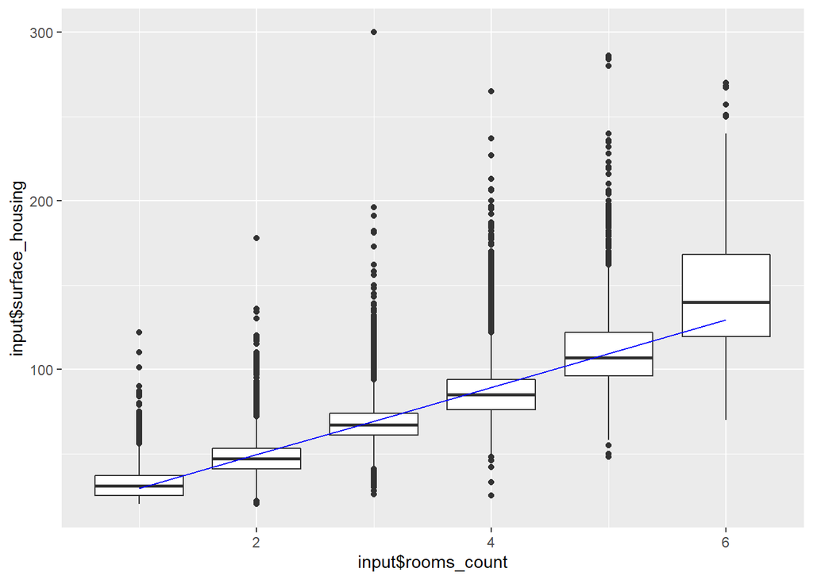

```r
ggplot() + geom_boxplot(data=input, aes(input$rooms_count, input$surface_housing, group=input$rooms_count) , main="room vs surface") + geom_line(data=input, aes(input$rooms_count, surface_room_yhat), color="blue")
```

خط رگرسیون در این قسمت نیز نشان دهنده این رابطه ی خطی است و تقریبا به جز یک سری داده پرت ساندویچ شده است و روی میانه هست و بین چارک اول و دوم قرار دارد.

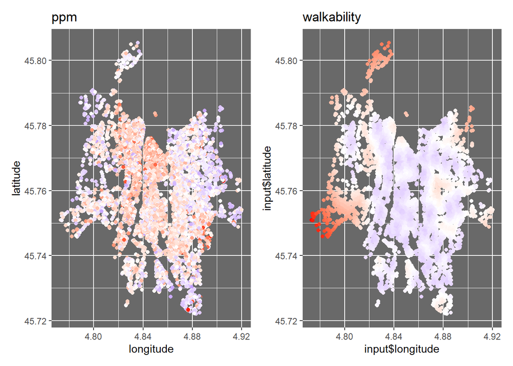

```r
library(patchwork)

(ggplot() + ggtitle("ppm") +
  geom_point(data=input, aes(y=latitude, x=longitude, color=ppm), show.legend = FALSE) +
  scale_color_gradient2(low = "blue", midpoint = sqrt(var(ppm)) * 0 + mean(ppm), high = "red", limits=c(sqrt(var(ppm)) * (-5) + mean(ppm) , sqrt(var(ppm)) * 5 + mean(input$ppm))) +
  theme(panel.background = element_rect(fill = "dimgray"))) +
(ggplot() + ggtitle("walkability") +
geom_point(data=input, aes(y=input$latitude, x=input$longitude, color=input$walkability), show.legend = FALSE) +
  scale_color_gradient2(low = "blue", midpoint = 550, high = "red") +
  theme(panel.background = element_rect(fill = "dimgray")))
```

در این قسمت دو نمودار مسافت بین خانه تا نزدیک ترین مترو و قیمت خانه را در کنار هم نشان داده ام که میتوان دید در مرکز شهر که پیاده روی کمی تا مترو هست قیمت خانه ها بالا است و در سمت چپ و حومه شهر که پیاده روی زیاد است قیمت خانه ها کمتر میشود. و تقریبا رابطه ی معکوسی بین آنها برقرار است.

```r
price_over_time = aggregate(input[, 16], list(substr(as.character(input$date_transaction), 1, 4)), mean)
reg_price_over_time = lm(data=price_over_time, price_over_time$x ~ order(price_over_time$Group.1))
summary(reg_price_over_time)
```

```
##
## Call:
## lm(formula = price_over_time$x ~ order(price_over_time$Group.1),
##     data = price_over_time)
##
## Residuals:
##       1       2       3       4       5       6
##   6.564  60.892 -49.080 -93.128  57.105  17.646
##
## Coefficients:
##                                Estimate Std. Error t value Pr(>|t|)
## (Intercept)                     3156.15      63.15   49.98 9.59e-07 ***
## order(price_over_time$Group.1)   250.59      16.22   15.45 0.000102 ***
## ---
## Signif. codes:  0 '***' 0.001 '**' 0.01 '*' 0.05 '.' 0.1 ' ' 1
##
## Residual standard error: 67.83 on 4 degrees of freedom
## Multiple R-squared:  0.9835, Adjusted R-squared:  0.9794
## F-statistic: 238.8 on 1 and 4 DF,  p-value: 0.0001023
```

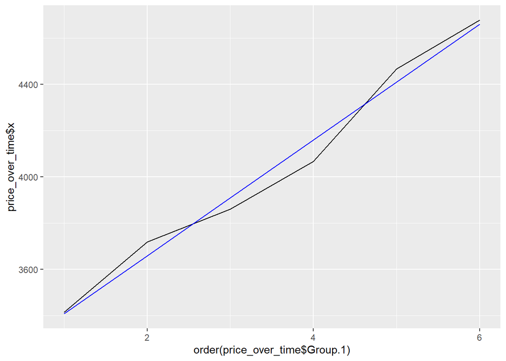

```r
price_over_time_yhat = predict(reg_price_over_time, price_over_time)
ggplot() + geom_line(aes(x=order(price_over_time$Group.1), y=price_over_time$x)) + geom_line(data=price_over_time, aes(order(price_over_time$Group.1), price_over_time_yhat), color="blue")
```

در این نمودار میانگین قیمت خانه ها را ر طی سال های متوالی نشان داده ام. هم از روی نمودار و هم با توجه به r squared مشخص است که میانگین قیمت در طی سال های متوالی رشد داشته است و زمان و قیمت رابطه ی خطی دارند.

#part c

```r
desired_houses = copy(input)
```

یک کپی از دیتای اصلی میگیرم که تغییرات لازم را روی آن انجام دهم.

```r
dist_to_uni = vector()
for (house in 1:length(desired_houses$price)){
  lat1 = desired_houses[house, 12]
  lon1 = desired_houses[house, 13]
  lat2 = 45.780234113880425
  lon2 = 4.865561717882041
  dist = distm(c(lon1, lat1), cbind(lon2, lat2), fun = distHaversine)
  dist_to_uni = c(dist_to_uni, dist)
}
```

در این بخش فاصله تا دانشگاه را برای هر خانه حساب میکنم و یک ستون جدید اضافه میکنم.

```r
desired_houses[, 17] = dist_to_uni
names(desired_houses)[17] = "dist_to_uni"
```

```r
desired_houses_copy = copy(desired_houses)
```

```r
delOutstylingHouses <- function(u_dist, m_dist, p_value, s_area, desired_houses_copy){

  rs = which(desired_houses_copy$dist_to_uni > u_dist)
  desired_houses_copy = desired_houses_copy[-c(rs), ]

  rs = which(desired_houses_copy$walkability > m_dist)
  desired_houses_copy = desired_houses_copy[-c(rs), ]

  rs = which(desired_houses_copy$price > p_value)
  desired_houses_copy = desired_houses_copy[-c(rs), ]

  rs = which(desired_houses_copy$surface_housing < s_area)
  desired_houses_copy = desired_houses_copy[-c(rs), ]

  return(desired_houses_copy)
}
```

در این قسمت یک تابع دارم که مقادیر نامطلوب را حذف میکند. خانه های با قیمت بیشتر از یک حد حذف می شوند. خانه های با فاصله از حدی بیشتر از مترو یا دانشگاه حذف می شوند و خانه های با مساحت کمتر از یک مقدار نیز حذف می شوند. و یک سری خانه مطلوب تر به دست می آید.

```r
desired_houses_copy = delOutstylingHouses(4000, 500, 150000, 50, desired_houses_copy)
```

```r
desired_houses_copy$price = desired_houses_copy$price / mean(desired_houses_copy$price)
desired_houses_copy$dist_to_uni = desired_houses_copy$dist_to_uni / mean(desired_houses_copy$dist_to_uni)
desired_houses_copy$surface_housing = desired_houses_copy$surface_housing / mean(desired_houses_copy$surface_housing)
desired_houses_copy$walkability = desired_houses_copy$walkability / mean(desired_houses_copy$walkability)
```

در این بخش مقادیری که میخواهم با یک ضریب با هم مقایسه کنم را به میانگین آنها تقسیم میکنم تا مقایسه بهتری انجام شود.

```r
L1 = 1.5
L2 = 1
L3 = 0.8
L4 = 1.5
desired_houses_copy$target = L1 * desired_houses_copy$price +
                              L2 * desired_houses_copy$dist_to_uni +
                              L3 * desired_houses_copy$surface_housing +
                              L4 * desired_houses_copy$walkability
```

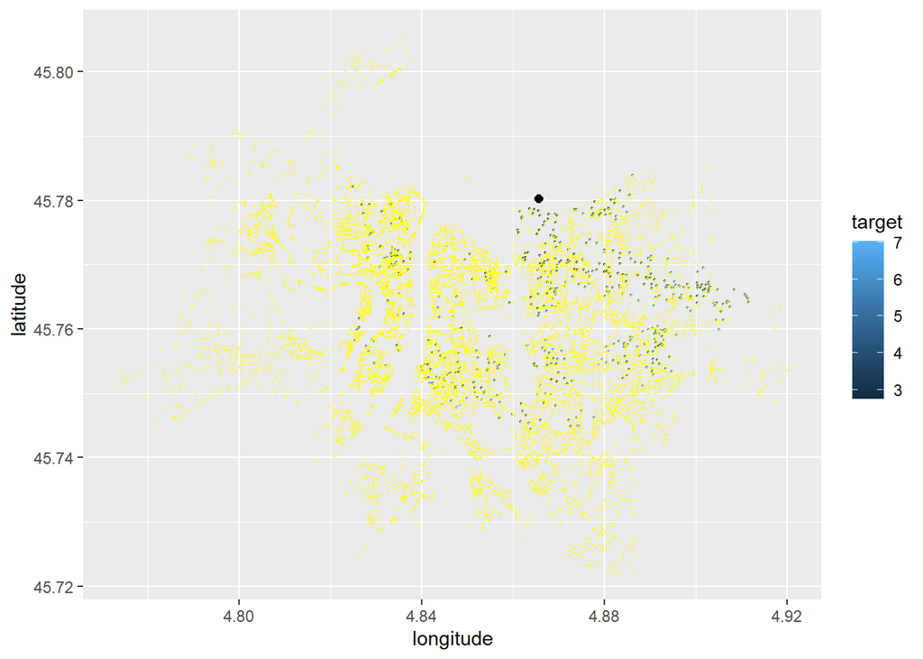

```r
ggplot() + geom_point( data=desired_houses_copy, aes(y=latitude, x=longitude, color = target), size = 0.4) + geom_point(aes(y=45.780234113880425, x=4.865561717882041), size=2) + geom_point(data=desired_houses, aes(y=latitude, x=longitude), size = 0.2, color = "yellow")
```

نمودار بالا ایجاد می شود که نشان دهنده مطلوبیت هر خانه است.

```r
desired_houses_co = desired_houses_copy[order(desired_houses_copy$target),]
```

```r
df = head(desired_houses_co)
```

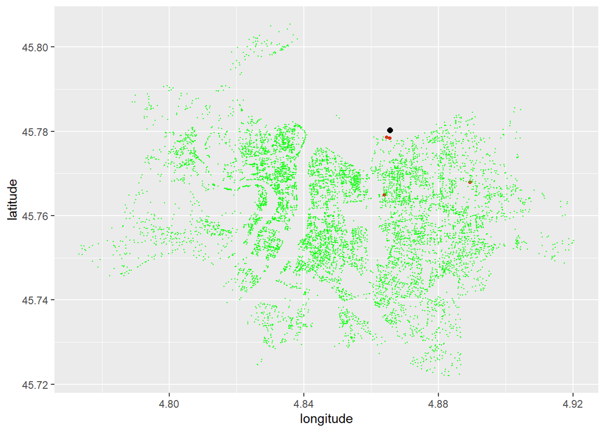

```r
ggplot() + geom_point( data=df, aes(y=latitude, x=longitude), color = "red", size = 1, show.legend = FALSE) + geom_point(aes(y=45.780234113880425, x=4.865561717882041), size=2) + geom_point(data=desired_houses, aes(y=latitude, x=longitude), size = 0.2, color = "green")
```

در نهایت بر اساس ستون اضافه شده سورت میکنم و چند خانه مینیمم را جدا میکنم. در نهایت دقت شود که این خانه ها ممکن است به فروش رفته باشند و منظور این است که محدوده اطراف خانه مطلوب است و در آنجا میتوان دنبال خانه گشت.